# DATA605 Week 9 Discussion Post

Andrew Bowen

2023-03-21

```r
library(glue)
library(ggplot2)
```

## Exercise 9.3.9

**How large must n be before $S_n = X_1 +X_2 + \dots + X_n$ is approximately normal? This number is often surprisingly small. Let us explore this question with a computer simulation. Choose n numbers from $[0, 1]$ with probability density $f(x)$, where $n = 3, 6, 12, 20$, and $f(x)$ is each of the densities in Exercise 7. Compute their sum Sn, repeat this experiment 1000 times, and make up a bar graph of 20 bars of the results. How large must n be before you get a good fit?**

We can perform this operation computationally

```r
set.seed(1234)
sample_sizes <- c(3, 6, 12, 20)
n_trials <- 1000
```

1. $f(x) = 1$ This corresponds to a uniform distribution, so we can use the built-in `runif` function from R

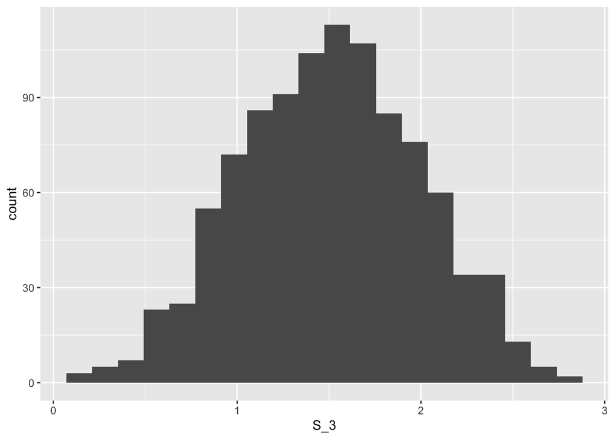

```r
df <- data.frame(S_3=c(1:1000),
                 S_6=c(1:1000),
                 S_12=c(1:1000),
                 S_20=c(1:1000))
for (n in sample_sizes){
  trial_sums <- c()
  for (i in seq(1, 1000)){
    t <- sum(runif(n))
    trial_sums <- append(trial_sums, t)
  }
  df[glue('S_{n}')] <- trial_sums
}


ggplot(df, aes(x=S_3)) + geom_histogram(bins=20)
```

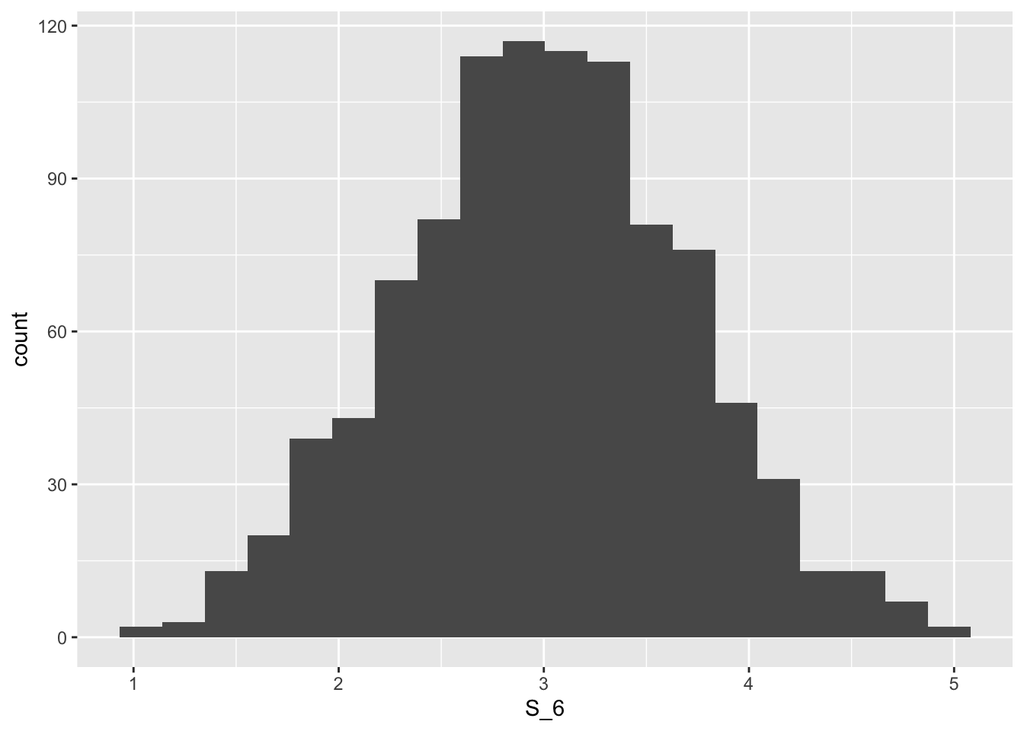

```r
# Sample size of 6
ggplot(df, aes(x=S_6)) + geom_histogram(bins=20)
```

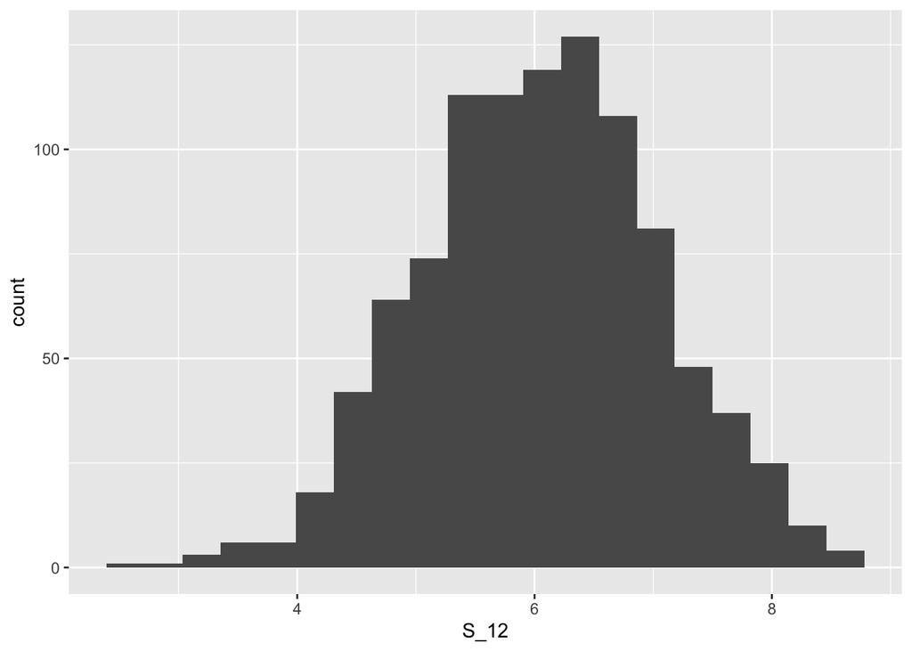

```r
# Sample size of 12
ggplot(df, aes(x=S_12)) + geom_histogram(bins=20)
```

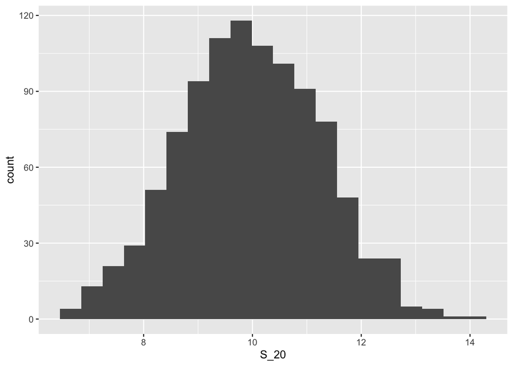

```r
# Sample size of 20
ggplot(df, aes(x=S_20)) + geom_histogram(bins=20)
```

2. $f(x) = 2x$ Here we’ll need to define a custom PDF from which we can sample from. We can do this by definition our probability density function `f` as an R function, then feed that function a vector sampled from a uniform distribution between $[0,1]$. For further reference check [this RPubs](https://rpubs.com/a_pear_9/weird_distributions)

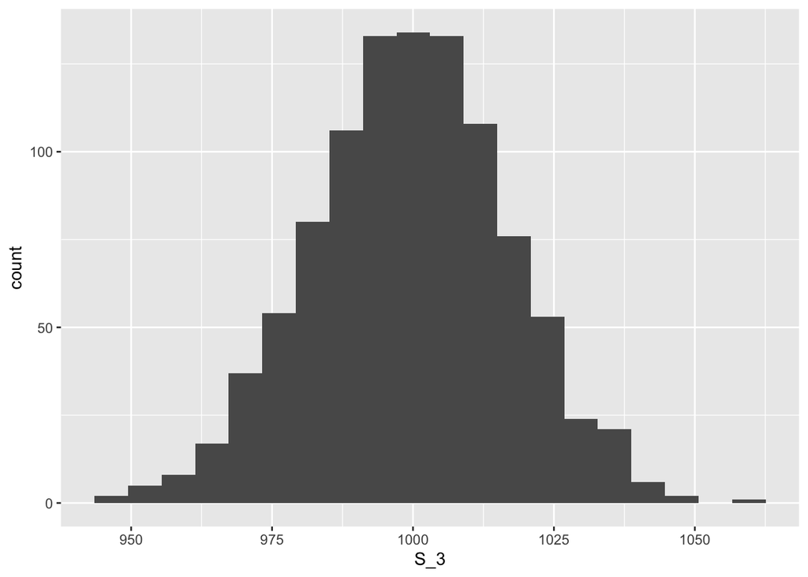

```r
df <- data.frame(S_3=c(1:1000),
                 S_6=c(1:1000),
                 S_12=c(1:1000),
                 S_20=c(1:1000))

f <- function(x){2 *x} # custom PDF
for (n in sample_sizes){
  trial_sums <- c()
  for (i in seq(1, n_trials)){
    u <- runif(n_trials)
    r <- f(u)
    t <- sum(r)
    trial_sums <- append(trial_sums, t)
  }
  df[glue('S_{n}')] <- trial_sums
}


ggplot(df, aes(x=S_3)) + geom_histogram(bins=20)
```

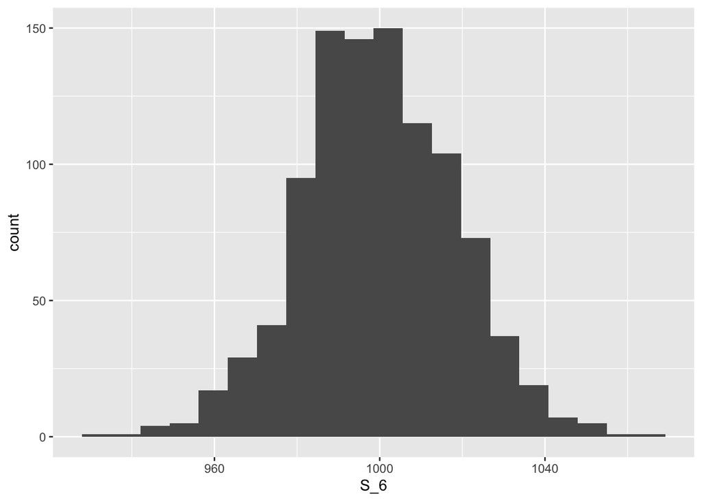

```r
# Sample size of 6
ggplot(df, aes(x=S_6)) + geom_histogram(bins=20)
```

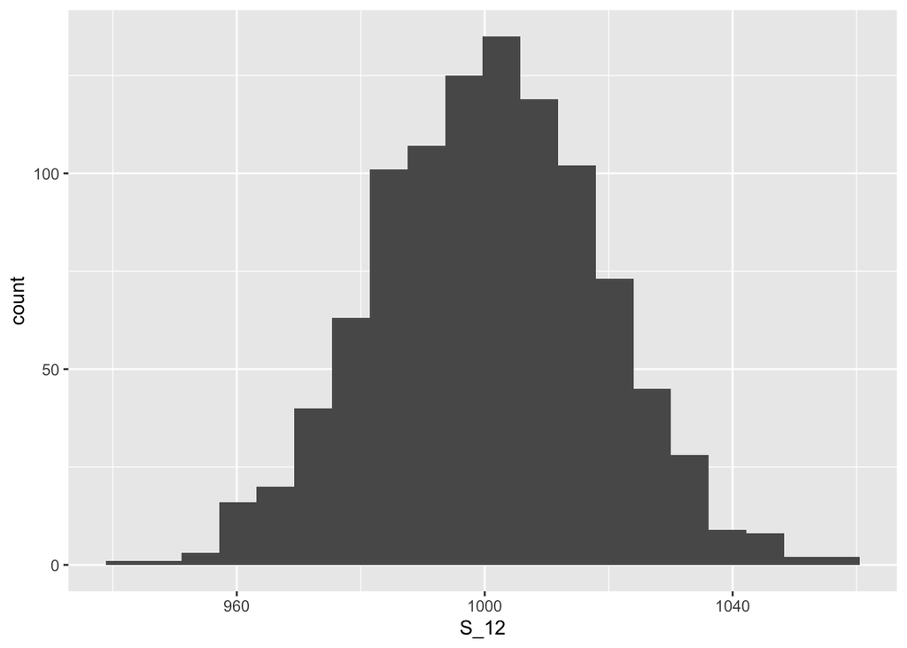

```r
# Sample size of 12
ggplot(df, aes(x=S_12)) + geom_histogram(bins=20)
```

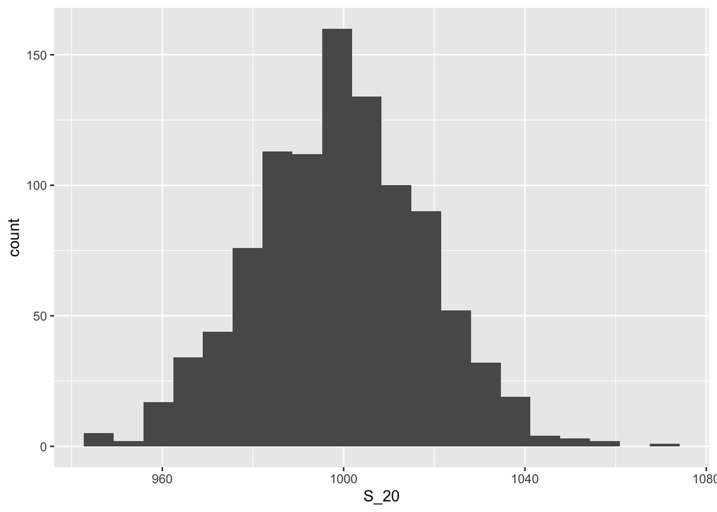

```r
# Sample size of 20
ggplot(df, aes(x=S_20)) + geom_histogram(bins=20)
```

3. $f(x) = 3x^2$ Again, we’ll define a custom pdf here: `f`, and feed it random values sampled from the uniform distribution

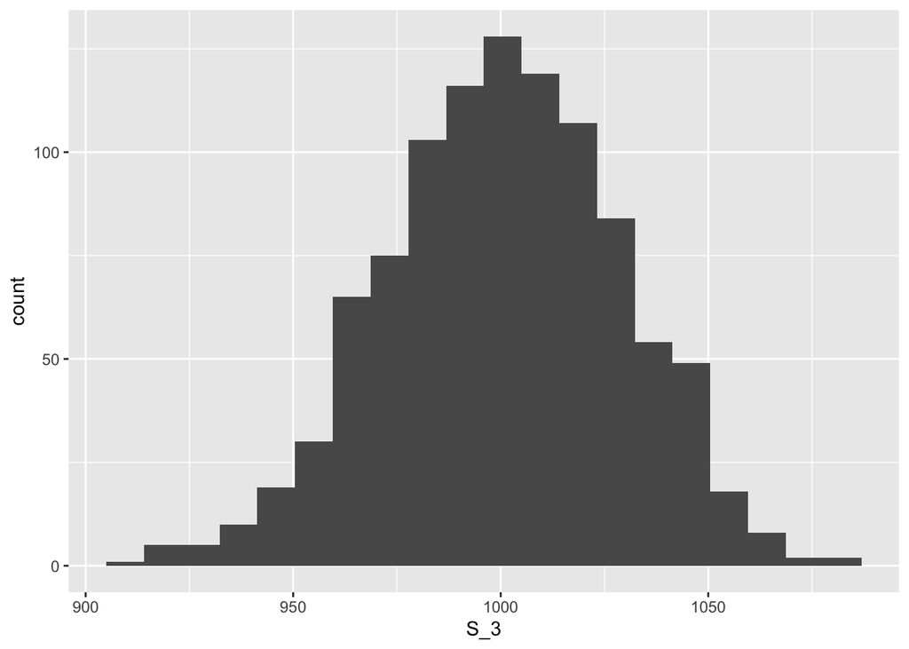

```r
df <- data.frame(S_3=c(1:1000),
                 S_6=c(1:1000),
                 S_12=c(1:1000),
                 S_20=c(1:1000))

f <- function(x){3 * (x**2)} # custom PDF
for (n in sample_sizes){
  trial_sums <- c()
  for (i in seq(1, n_trials)){
    u <- runif(n_trials)
    r <- f(u)
    t <- sum(r)
    trial_sums <- append(trial_sums, t)
  }
  df[glue('S_{n}')] <- trial_sums
}


ggplot(df, aes(x=S_3)) + geom_histogram(bins=20)
```

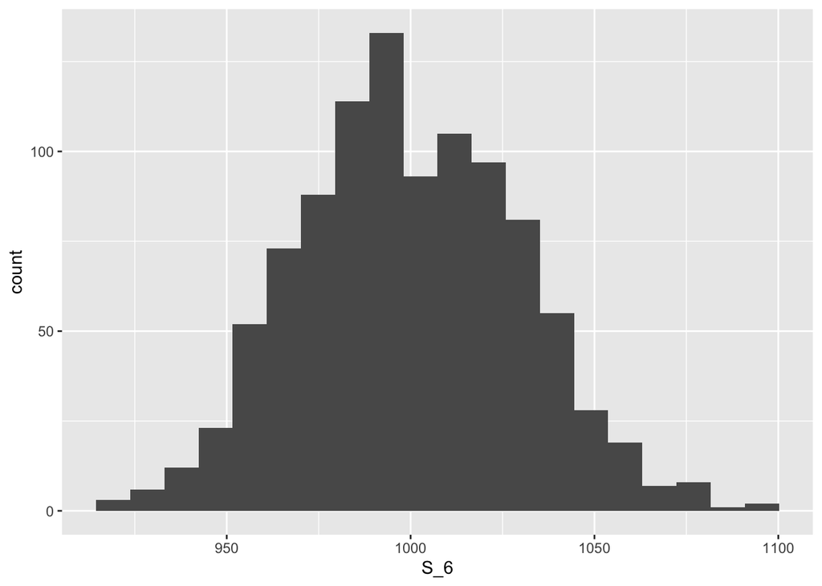

```r
# Sample size of 6
ggplot(df, aes(x=S_6)) + geom_histogram(bins=20)
```

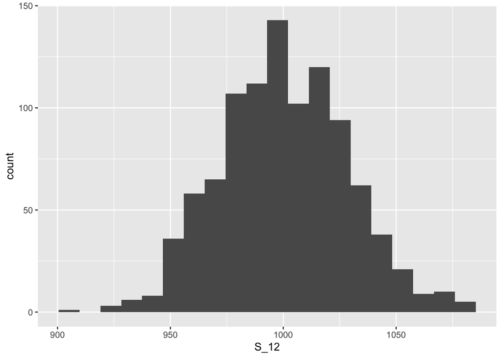

```r
# Sample size of 12
ggplot(df, aes(x=S_12)) + geom_histogram(bins=20)
```

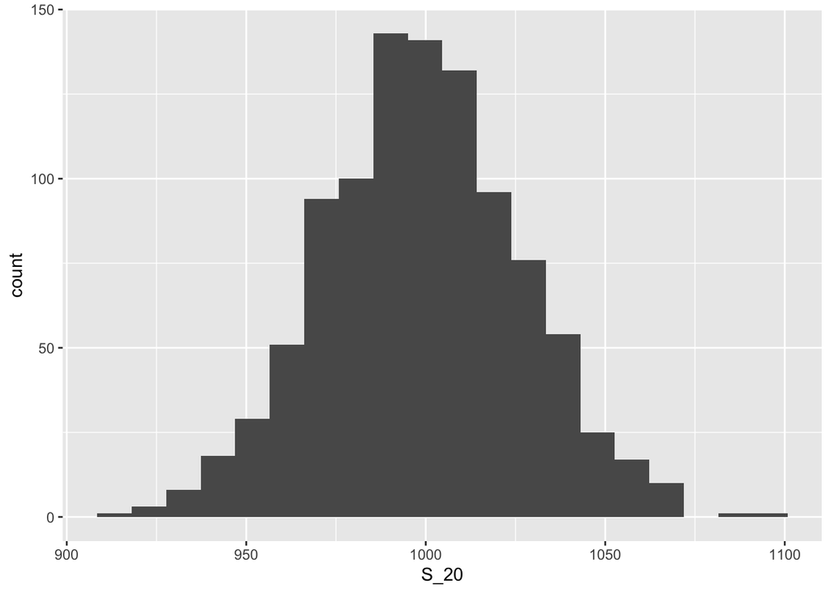

```r
# Sample size of 20
ggplot(df, aes(x=S_20)) + geom_histogram(bins=20)
```

4. $f(x)=4|x−1/2|$

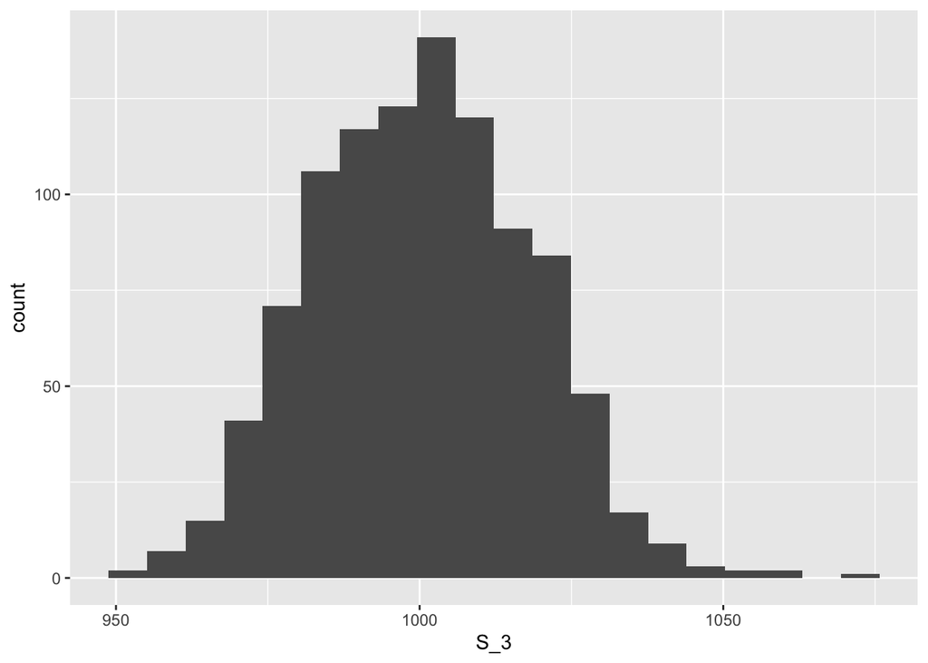

```r
df <- data.frame(S_3=c(1:1000),
                 S_6=c(1:1000),
                 S_12=c(1:1000),
                 S_20=c(1:1000))

f <- function(x){4 * abs(x - (1/2))} # custom PDF
for (n in sample_sizes){
  trial_sums <- c()
  for (i in seq(1, n_trials)){
    u <- runif(n_trials)
    r <- f(u)
    t <- sum(r)
    trial_sums <- append(trial_sums, t)
  }
  df[glue('S_{n}')] <- trial_sums
}


ggplot(df, aes(x=S_3)) + geom_histogram(bins=20)
```

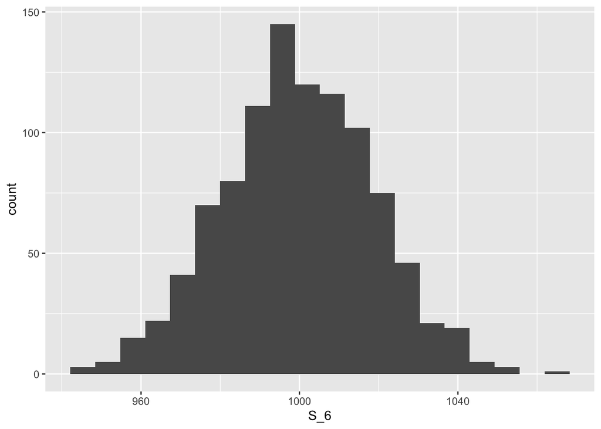

```r
# Sample size of 6
ggplot(df, aes(x=S_6)) + geom_histogram(bins=20)
```

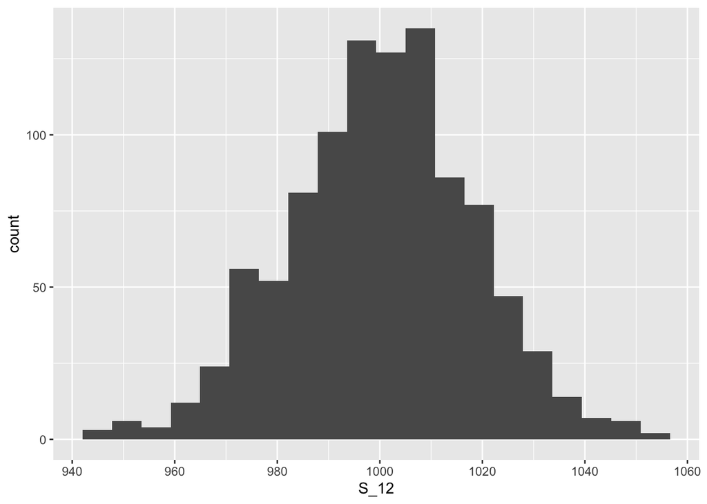

```r
# Sample size of 12
ggplot(df, aes(x=S_12)) + geom_histogram(bins=20)
```

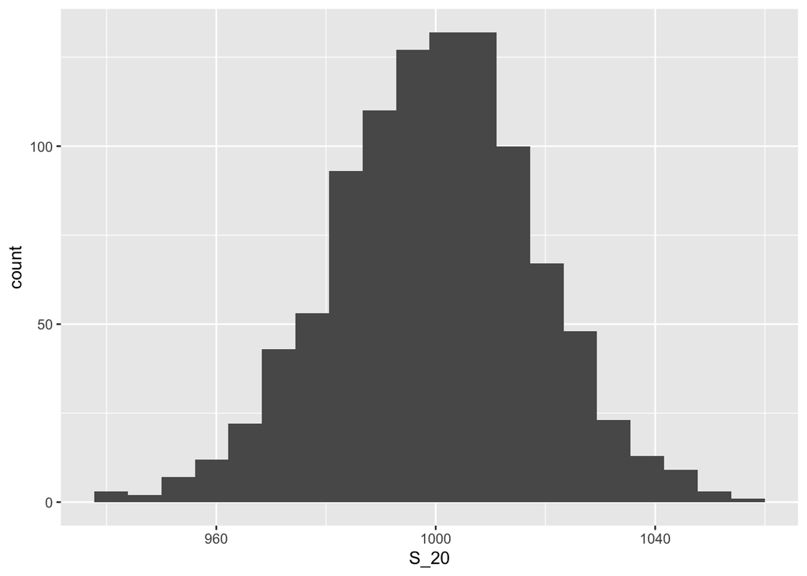

```r
# Sample size of 20
ggplot(df, aes(x=S_20)) + geom_histogram(bins=20)
```

e. $f(x)=2−4|x−1/2|$

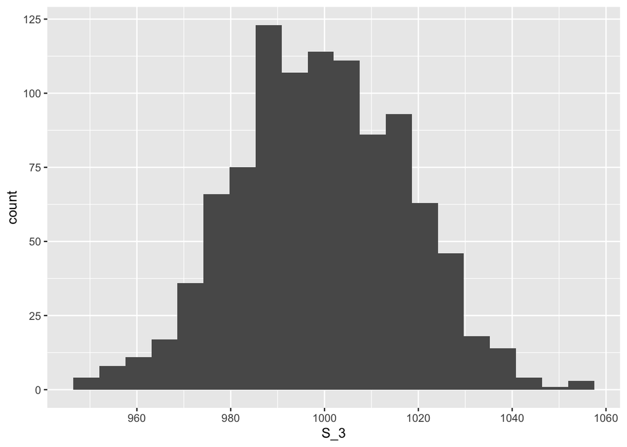

```r
df <- data.frame(S_3=c(1:1000),
                 S_6=c(1:1000),
                 S_12=c(1:1000),
                 S_20=c(1:1000))

f <- function(x){2 - (4 * abs(x - (1/2)))} # custom PDF
for (n in sample_sizes){
  trial_sums <- c()
  for (i in seq(1, n_trials)){
    u <- runif(n_trials)
    r <- f(u)
    t <- sum(r)
    trial_sums <- append(trial_sums, t)
  }
  df[glue('S_{n}')] <- trial_sums
}


ggplot(df, aes(x=S_3)) + geom_histogram(bins=20)
```

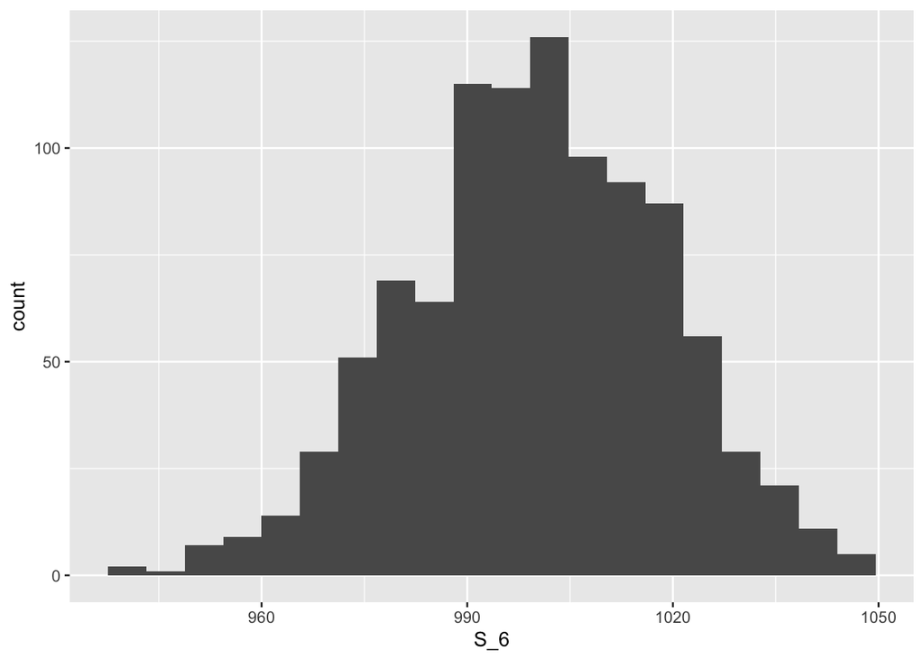

```r
# Sample size of 6
ggplot(df, aes(x=S_6)) + geom_histogram(bins=20)
```

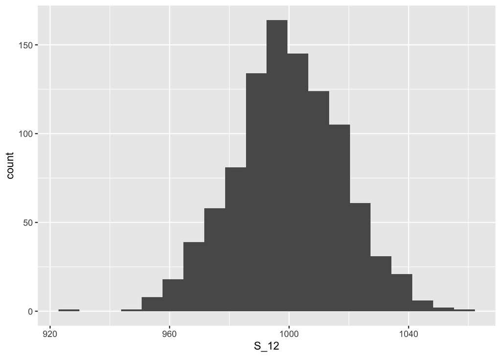

```r
# Sample size of 12
ggplot(df, aes(x=S_12)) + geom_histogram(bins=20)
```

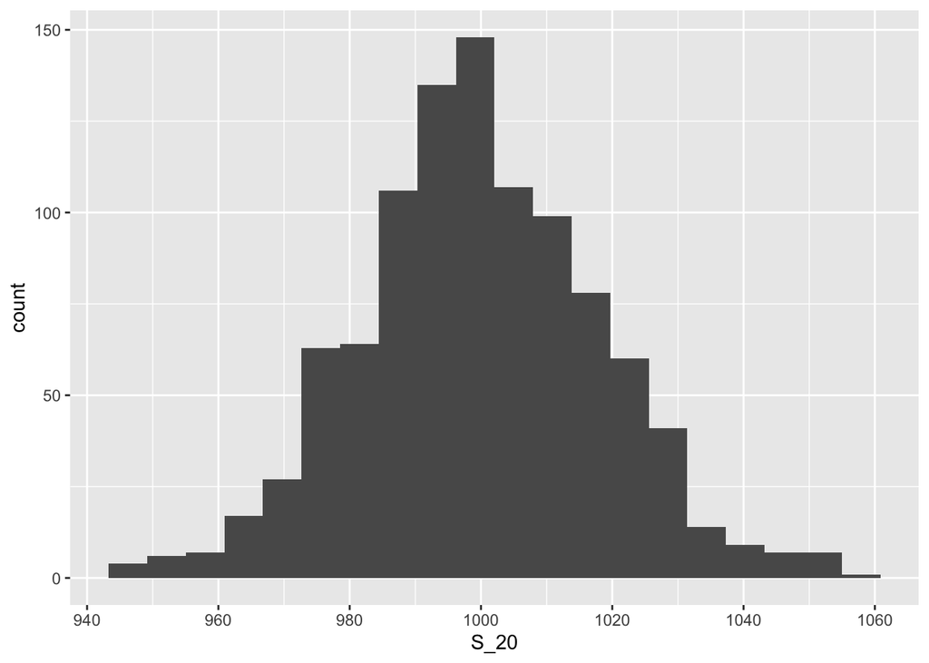

```r
# Sample size of 20
ggplot(df, aes(x=S_20)) + geom_histogram(bins=20)
```

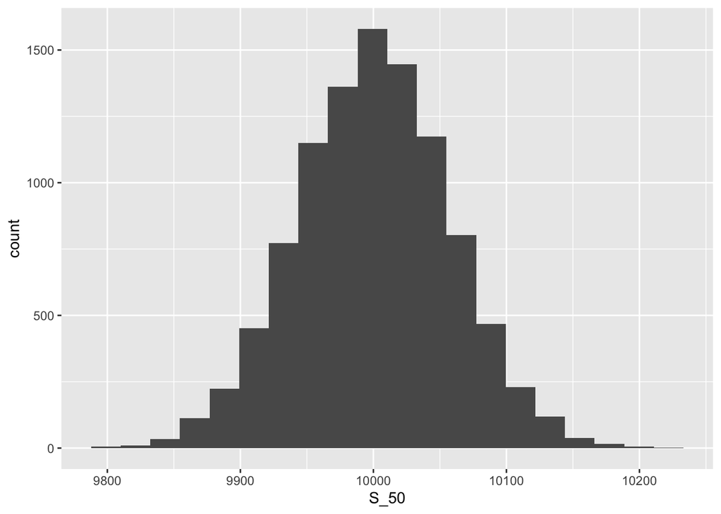

```r
n_trials <- 10000 # larger number of trials
df <- data.frame(S_50=c(1:n_trials),
                 S_500=c(1:n_trials),
                 S_5000=c(1:n_trials)
                 )
sample_sizes <- c(50, 500, 5000)

f <- function(x){2 - (4 * abs(x - (1/2)))} # custom PDF
for (n in sample_sizes){
  trial_sums <- c()
  for (i in seq(1, n_trials)){
    u <- runif(n_trials)
    r <- f(u)
    t <- sum(r)
    trial_sums <- append(trial_sums, t)
  }
  df[glue('S_{n}')] <- trial_sums
}

# Sample size of 50
ggplot(df, aes(x=S_50)) + geom_histogram(bins=20)
```

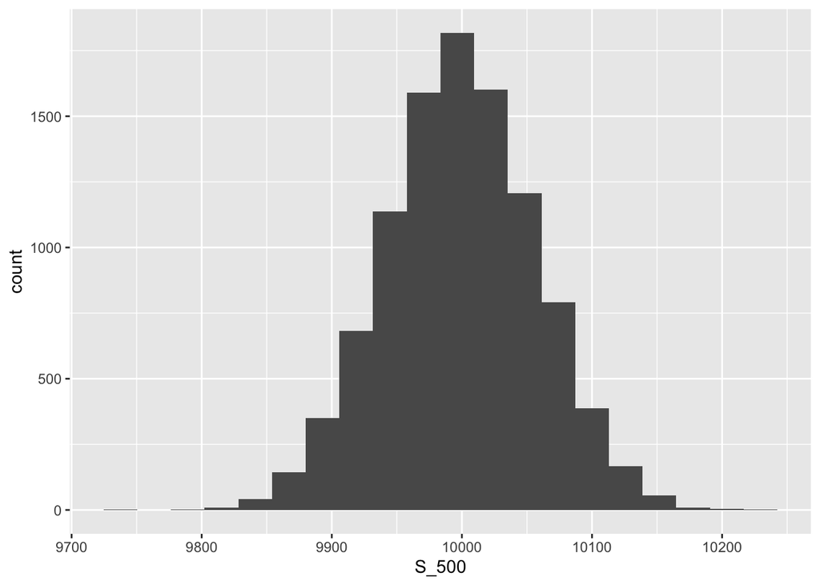

```r
# Sample size of 500
ggplot(df, aes(x=S_500)) + geom_histogram(bins=20)
```

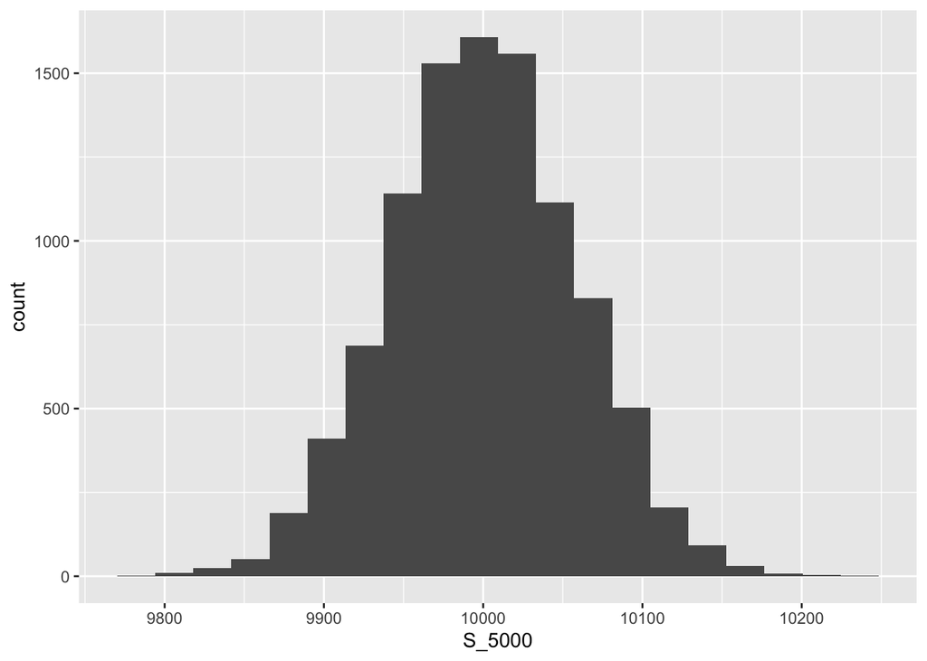

```r
# Sample size of 5000
ggplot(df, aes(x=S_5000)) + geom_histogram(bins=20)
```